# The World Bank and climate

Big Issues · Imperial College Business School

Ralf Martin

2 November 2026

## One group, five institutions

### “The World Bank” — lends to governments

- **IBRD** — middle-income countries, market-rate loans
- **IDA** — the poorest ~75 countries, grants and near-zero-interest credits

### The rest of the World Bank Group

- **IFC** — invests in the **private sector**: loans, equity, mobilising other investors *(where I worked)*
- **MIGA** — political-risk insurance and guarantees
- **ICSID** — investment dispute settlement

189 member countries. Finance raised by borrowing on capital markets against members’ capital, then lent on to developing countries.

## Mission: poverty *on a livable planet*

> **“To end extreme poverty and boost shared prosperity on a livable planet.”**

> — World Bank Group mission, adopted 2023 (the “Evolution Roadmap”)

#### Why climate is in it

The poor are hit first and hardest — floods, droughts, heat, crop failure.

#### Development needs energy

Hundreds of millions still lack electricity. The question is *which* energy.

#### Mainstreamed, not a silo

In FY25, **97%** of World Bank projects had a climate component.

## The largest climate financier of developing countries

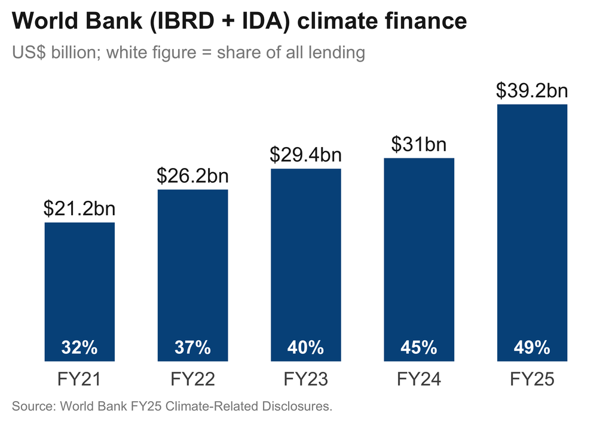

$50.8bn

Group-wide climate finance in FY25

- IBRD $22.5bn · IDA $16.7bn
- IFC $8.1bn · MIGA $3.5bn

$190bn

over FY21–25

In the poorest (IDA) countries, **over half** goes to **adaptation**.

## Where the climate money goes

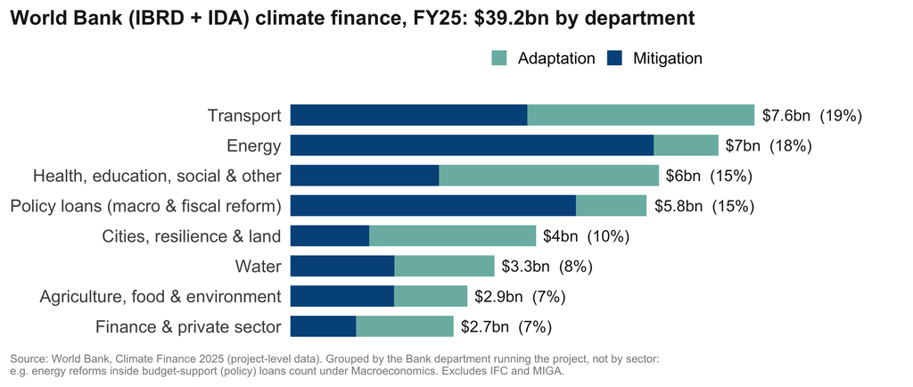

## A pioneer in clean power markets

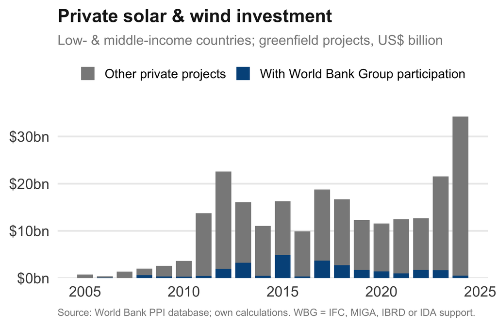

**From ~$1bn a year in the mid-2000s to $34bn in 2024.**

WBG share of that investment:

| Period | WBG share | Any MDB |
| --- | --- | --- |
| 2005-10 | 13% | 24% |
| 2011-15 | 14% | 25% |
| 2016-20 | 14% | 28% |
| 2021-24 | 6% | 25% |

A country’s **first** private solar/wind deals were **twice as likely** to have multilateral backing as its later deals (45% vs 21%).

## My work: innovation in green technologies

**IFC Insights Report (2025): *Innovation in Green Technologies***

- Developing countries (ex China) produce **< 1%** of global green innovation…
- …but their green innovations are **cited more** than average, and match rich-country innovation in economic value

**My hypothesis:** developing countries need *more* of their own innovation —

1. **for growth** — new technology waves (electronics in Korea and Taiwan, green tech in China) are how countries catch up
2. **for climate solutions that fit** — technologies designed for local climate, conditions and adaptation needs that rich-country R&D won’t prioritise

[figure not shown]

[IFC report](https://www.ifc.org/en/insights-reports/2025/innovation-in-green-technologies)

## New: who does innovation in developing countries?

#### New paper — CEP DP 2223 (Oct 2026)

*Innovation partnerships for development along green value chains*

[figure not shown]

Partnerships with rich-country firms account for **~2%** of rich-country innovation but **almost half** of developing-country innovation — and produce the highest-value innovations.

#### EMDERLT — Research Lab Tracker

*Map of ~2,000 verified R&D labs in developing countries*

[figure not shown]

Who invents what, where — free to explore and download.

Questions?